# hotel_wordcloud

```python
import pandas as pd
import spacy
from tqdm import tqdm
from wordcloud import WordCloud
import matplotlib.pyplot as plt
```

```python
def get_tokens(doc):
    return [t.norm_ for t in doc]
```

```python
import spacy

mwt = spacy.load('mwt_model')
```

```python
df = pd.read_parquet("hotel_review.parquet")
```

```python
def get_tokens(doc):
    return [t.norm_ for t in doc]

# Tokenize the reviews
df['tokens'] = list(map(get_tokens, mwt.pipe(tqdm(df["text"]), batch_size=100, n_process=2)))
```

```python
def generate_wordcloud(text):
    wordcloud = WordCloud(width = 800, height = 800,
                background_color ='white',
                stopwords = None,
                min_font_size = 10).generate(' '.join(text))
    return wordcloud
```

```python
positive_reviews = df[df['overall'] == 5]['text']
negative_reviews = df[df['overall'] == 1]['text']
```

```python
positive_tokens = list(map(get_tokens, mwt.pipe(positive_reviews)))
negative_tokens = list(map(get_tokens, mwt.pipe(negative_reviews)))
```

```python
def generate_wordcloud(tokens, title):
    wordcloud = WordCloud(width=800, height=800, background_color='white', min_font_size=10).generate(' '.join(tokens))
    plt.figure(figsize=(8, 8), facecolor=None)
    plt.imshow(wordcloud)
    plt.axis("off")
    plt.tight_layout(pad=0)
    plt.title(title)
    plt.show()
```

```python
def flatten_list(list_of_lists):
    return [item for sublist in list_of_lists for item in sublist]
```

```python
positive_tokens_flat = flatten_list(positive_tokens)
negative_tokens_flat = flatten_list(negative_tokens)
```

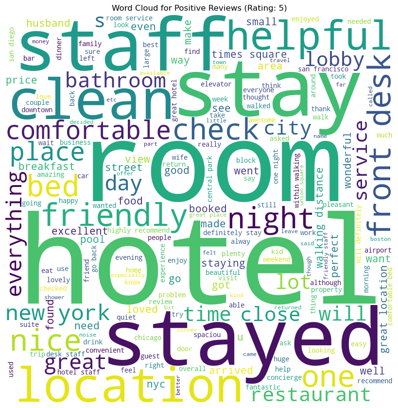

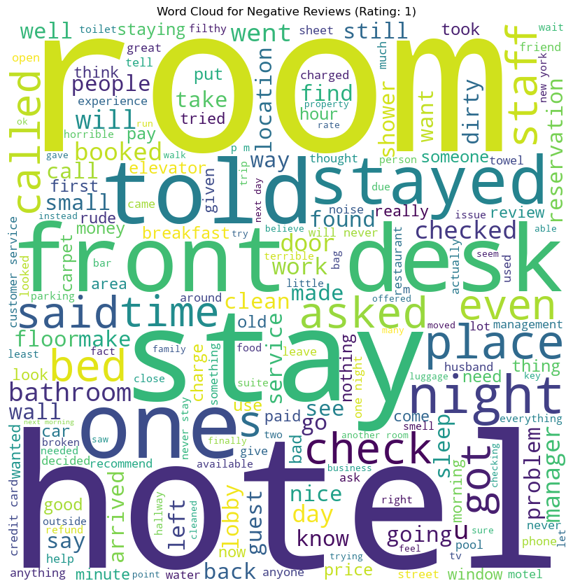

```python
positive_wordcloud = generate_wordcloud(positive_tokens_flat, 'Word Cloud for Positive Reviews (Rating: 5)')
negative_wordcloud = generate_wordcloud(negative_tokens_flat, 'Word Cloud for Negative Reviews (Rating: 1)')
```

In analyzing the Hotel reviews dataset, we employed a multiword tokenizer MWT to preprocess the text data, enabling a more comprehensive understanding of the reviews. After tokenization, we segregated the reviews based on their overall ratings, focusing on reviews rated either 1 or 5 stars. Subsequently, we generated word clouds for both positive (5-star) and negative (1-star) reviews to visualize the most frequent terms used within each category. The word clouds revealed distinct patterns in the language used by customers in their evaluations.

Positive reviews commonly highlighted words associated with satisfaction and positive experiences, such as "comfortable," "clean", "helpful", "friendly staff" and "service".

Conversely, negative reviews exhibited a prevalence of terms indicating dissatisfaction or problems encountered during the stay, including "terrible," "bathrooms", "rude" and "broken." Overall, the word clouds provided valuable insights into the key aspects that contribute to guests' perceptions of their hotel experiences, facilitating a deeper understanding of customer sentiment and areas for potential improvement in hospitality services.